# Practical-homework3

```python
#Load libraries
import pandas as pd
import numpy as np
import librosa
import matplotlib.pyplot as plt
import librosa.display

import os

from sklearn.model_selection import train_test_split
from sklearn.linear_model import LinearRegression, LassoCV
from sklearn.metrics import mean_squared_error, r2_score
from sklearn.preprocessing import StandardScaler
from sklearn.metrics import mean_absolute_error

!pip install tensorflow
from tensorflow.keras.preprocessing.sequence import pad_sequences

from keras.models import Sequential
from keras.layers import Dense, Dropout, Activation, Flatten, Conv2D, MaxPooling2D
from keras.utils import to_categorical
from keras.applications import ResNet50
from keras.applications import imagenet_utils
from keras.applications.resnet import preprocess_input
```

```python
#Load and check for shape of HDF5 file:

import h5py

f = h5py.File('Bird data/bird_spectrograms.hdf5', 'r')
print(list(f.keys()))
dset = f['amecro']
print(dset.shape)
dset1= f['amerob']
print(dset1.shape)
```

```
['amecro', 'amerob', 'bewwre', 'bkcchi', 'daejun', 'houfin', 'houspa', 'norfli', 'rewbla', 'sonspa', 'spotow', 'whcspa']
(128, 517, 66)
(128, 517, 172)
```

Load HDF5 file, check key corresponds for each species, and inspect dataset shape.

```python
#Re-organize data to fit for CNN models
species_key = list(f.keys())

X_new_data = []
y_new_data = []

for species in species_key:
    bird_dataset= f[species]

    #Transpose dataset to correct order:
    X_bird= np.transpose(bird_dataset, (2,0,1))

    #Add extra channel dimmension to prep for CNN
    X_bird= X_bird[..., np.newaxis]

    #Create labels for each species:
    y_bird = np.array([species] * X_bird.shape[0])

    #Store values in the dataset
    X_new_data.append(X_bird)
    y_new_data.append(y_bird)

#Combine into one dataset
X_new= np.vstack(X_new_data)
print(X_new.shape)
y_new= np.concatenate(y_new_data)
print(y_new.shape)
```

```
(1981, 128, 517, 1)
(1981,)
```

Restructure raw spectrogram tensors into format that suitable for CNNs. Each dataset was transposed so sample dimension come first, and add additional channel to match what CNN usually look for. All species are stacked into single tenso X_new, their corresponding labels combined into y_new

```python
#Create Binary CNN model:
bird_A = 'amecro'
bird_B = 'sonspa'

binary_mask = (y_new == bird_A) | (y_new== bird_B)

X_binary = X_new[binary_mask]
y_binary= y_new[binary_mask]

#Convert labels to 0 and 1
y_binary_int= (y_binary == bird_B).astype(int)

#Train and test split for binary model
X_bin_train, X_bin_test, y_bin_train, y_bin_test = train_test_split(
    X_binary, y_binary_int,
    test_size =0.3,
    random_state = 42,
    stratify= y_binary_int
)

print(X_bin_train.shape)
```

```
(230, 128, 517, 1)
```

Amecro and sonspa was chose for binary classification. Boolean mask was applied to extract relevant samples, labels got converted into binary integers (0 for amecro, 1 for sonspa). The data got filtered and split into train and test sets

```python
#Build CNN model:
bin_model = Sequential([
    Conv2D(filters= 16, kernel_size = (3,3), activation = 'relu', padding = 'same' , input_shape= (128,517,1)),
    MaxPooling2D((2,2)),

    Conv2D(filters= 32, kernel_size= (3,3), activation= 'relu', padding = 'same'),
    MaxPooling2D((2,2)),

    Flatten(),
    Dropout(rate= 0.2),
    Dense(units= 32, activation = 'relu'),
    Dense(units= 1, activation= 'sigmoid')
])
bin_model.summary()

#Compile model
bin_model.compile(
    optimizer= 'rmsprop',
    loss= 'binary_crossentropy',
    metrics=['accuracy']
)

bin_model.fit(
    X_bin_train, y_bin_train,
    validation_split = 0.2,
    epochs= 20,
    batch_size = 30,
    verbose= 0 )

model_bin_train_loss, model_bin_train_acc = bin_model.evaluate (X_bin_train, y_bin_train, verbose = 0)
print ('Train accurate: ', model_bin_train_acc*100, '%')

model_bin_test_loss, model_bin_test_acc = bin_model.evaluate(X_bin_test, y_bin_test, verbose= 0)
print('Test accurate: ', model_bin_test_acc*100, '%')
```

```
Model: "sequential_12"
```

```
┏━━━━━━━━━━━━━━━━━━━━━━━━━━━━━━━━━┳━━━━━━━━━━━━━━━━━━━━━━━━┳━━━━━━━━━━━━━━━┓
┃ Layer (type)                    ┃ Output Shape           ┃       Param # ┃
┡━━━━━━━━━━━━━━━━━━━━━━━━━━━━━━━━━╇━━━━━━━━━━━━━━━━━━━━━━━━╇━━━━━━━━━━━━━━━┩
│ conv2d_32 (Conv2D)              │ (None, 128, 517, 16)   │           160 │
├─────────────────────────────────┼────────────────────────┼───────────────┤
│ max_pooling2d_30 (MaxPooling2D) │ (None, 64, 258, 16)    │             0 │
├─────────────────────────────────┼────────────────────────┼───────────────┤
│ conv2d_33 (Conv2D)              │ (None, 64, 258, 32)    │         4,640 │
├─────────────────────────────────┼────────────────────────┼───────────────┤
│ max_pooling2d_31 (MaxPooling2D) │ (None, 32, 129, 32)    │             0 │
├─────────────────────────────────┼────────────────────────┼───────────────┤
│ flatten_12 (Flatten)            │ (None, 132096)         │             0 │
├─────────────────────────────────┼────────────────────────┼───────────────┤
│ dropout_12 (Dropout)            │ (None, 132096)         │             0 │
├─────────────────────────────────┼────────────────────────┼───────────────┤
│ dense_24 (Dense)                │ (None, 32)             │     4,227,104 │
├─────────────────────────────────┼────────────────────────┼───────────────┤
│ dense_25 (Dense)                │ (None, 1)              │            33 │
└─────────────────────────────────┴────────────────────────┴───────────────┘
```

```
 Total params: 4,231,937 (16.14 MB)
```

```
 Trainable params: 4,231,937 (16.14 MB)
```

```
 Non-trainable params: 0 (0.00 B)
```

```
Train accurate:  97.39130139350891 %
Test accurate:  89.89899158477783 %
```

The binary classification consists of two convolution-pooling layer that extract time and frequency. Followed by flattening, dense, and final sigmoid activation outputs to present likelihood that input belongs to eiher sonspa or amecro. The model was also trained with 20 epochs with validation split of 0.2, to check whether the model is overfit or not.

```python
def predict_binary_mp3(Bird_data, bin_model, y_binary_int):
    #Load audio
    y_binary_mp3, sample_binary_rate= librosa.load(Bird_data, duration = 3)
    # Convert  to spectrogram:
    spectro_data_binary= librosa.feature.melspectrogram(
        y=y_binary_mp3, sr= sample_binary_rate,
        hop_length= 128,
        win_length= 512,
        n_mels= 128)

    #Reshape to fit convolution model:
    X_binary_mp3= spectro_data_binary[np.newaxis, ..., np.newaxis]

    #Predict mp3 files by using convolution model:
    pred_binary_mp3= bin_model.predict(X_binary_mp3)
    class_bin_index_mp3= np.argmax(pred_binary_mp3)
    species_bin= convert_int.inverse_transform([class_bin_index_mp3])[0]
    confidence_bin_mp3= pred_binary_mp3[0][class_bin_index_mp3]
    percent_bin_acc = confidence_bin_mp3 *100
    return species_bin, percent_bin_acc

#Test on fiirst mp3 files:
species1_bin, confidence1_bin= predict_binary_mp3('Bird data/test1.mp3', bin_model,y_binary_int)
print('Predicted: ', species1_bin, 'Percent accurate: ', confidence1_bin, '%')

#Test on second mp3 files:
species2_bin, confidence2_bin= predict_binary_mp3('Bird data/test2.mp3', bin_model,y_binary_int)
print('Predicted: ', species2_bin, 'Percent accurate: ', confidence2_bin, '%')

#Test on third mp3 files:
species3_bin, confidence3_bin= predict_binary_mp3('Bird data/test3.mp3', bin_model,y_binary_int)
print('Predicted: ', species3_bin, 'Percent accurate: ', confidence3_bin, '%')
```

```
1/1 ━━━━━━━━━━━━━━━━━━━━ 0s 63ms/step
Predicted:  amecro Percent accurate:  95.31345 %
1/1 ━━━━━━━━━━━━━━━━━━━━ 0s 25ms/step
Predicted:  amecro Percent accurate:  98.69604 %
1/1 ━━━━━━━━━━━━━━━━━━━━ 0s 25ms/step
Predicted:  amecro Percent accurate:  94.595375 %
```

```python
#Convert each species to integer
from sklearn.preprocessing import LabelEncoder
convert_int= LabelEncoder()
y_convert= convert_int.fit_transform(y_new)

#Normalize data:
X_new = X_new/255

#Train/test split
X_train, X_test, y_train, y_test= train_test_split(
    X_new, y_convert,
    test_size= 0.3,
    random_state= 42)
print( X_train.shape)
print(X_test.shape)

#Convert to multi class:
Y_train= to_categorical(y_train)
Y_test= to_categorical (y_test)
print(Y_train.shape)
print(Y_test.shape)
```

```
(1386, 128, 517, 1)
(595, 128, 517, 1)
(1386, 12)
(595, 12)
```

Species name got encoded into integer using LabelEncoder. Labels were converted into vector with one hot encode function.

```python
convo_model= Sequential ([
    Conv2D(filters =32, kernel_size= (3,3), activation = 'relu', padding = 'same' , input_shape= (128,517,1)),
    MaxPooling2D((2,2)),

    Conv2D(filters= 64, kernel_size= (3,3), activation='relu', padding='same'),
    MaxPooling2D((2,2)),

    Conv2D(filters= 128, kernel_size = (3,3), activation='relu', padding='same'),
    MaxPooling2D((2,2)),

    Conv2D(filters= 256, kernel_size=(3,3), activation='relu', padding='same'),
    MaxPooling2D((2,2)),

    Flatten(),
    Dropout(rate=0.3),
    Dense(units= 128, activation = 'relu'),
    Dense(units =12, activation= 'softmax')
])

convo_model.summary()
```

```
Model: "sequential_13"
```

```
┏━━━━━━━━━━━━━━━━━━━━━━━━━━━━━━━━━┳━━━━━━━━━━━━━━━━━━━━━━━━┳━━━━━━━━━━━━━━━┓
┃ Layer (type)                    ┃ Output Shape           ┃       Param # ┃
┡━━━━━━━━━━━━━━━━━━━━━━━━━━━━━━━━━╇━━━━━━━━━━━━━━━━━━━━━━━━╇━━━━━━━━━━━━━━━┩
│ conv2d_34 (Conv2D)              │ (None, 128, 517, 32)   │           320 │
├─────────────────────────────────┼────────────────────────┼───────────────┤
│ max_pooling2d_32 (MaxPooling2D) │ (None, 64, 258, 32)    │             0 │
├─────────────────────────────────┼────────────────────────┼───────────────┤
│ conv2d_35 (Conv2D)              │ (None, 64, 258, 64)    │        18,496 │
├─────────────────────────────────┼────────────────────────┼───────────────┤
│ max_pooling2d_33 (MaxPooling2D) │ (None, 32, 129, 64)    │             0 │
├─────────────────────────────────┼────────────────────────┼───────────────┤
│ conv2d_36 (Conv2D)              │ (None, 32, 129, 128)   │        73,856 │
├─────────────────────────────────┼────────────────────────┼───────────────┤
│ max_pooling2d_34 (MaxPooling2D) │ (None, 16, 64, 128)    │             0 │
├─────────────────────────────────┼────────────────────────┼───────────────┤
│ conv2d_37 (Conv2D)              │ (None, 16, 64, 256)    │       295,168 │
├─────────────────────────────────┼────────────────────────┼───────────────┤
│ max_pooling2d_35 (MaxPooling2D) │ (None, 8, 32, 256)     │             0 │
├─────────────────────────────────┼────────────────────────┼───────────────┤
│ flatten_13 (Flatten)            │ (None, 65536)          │             0 │
├─────────────────────────────────┼────────────────────────┼───────────────┤
│ dropout_13 (Dropout)            │ (None, 65536)          │             0 │
├─────────────────────────────────┼────────────────────────┼───────────────┤
│ dense_26 (Dense)                │ (None, 128)            │     8,388,736 │
├─────────────────────────────────┼────────────────────────┼───────────────┤
│ dense_27 (Dense)                │ (None, 12)             │         1,548 │
└─────────────────────────────────┴────────────────────────┴───────────────┘
```

```
 Total params: 8,778,124 (33.49 MB)
```

```
 Trainable params: 8,778,124 (33.49 MB)
```

```
 Non-trainable params: 0 (0.00 B)
```

Convolutional Neural Network designed to classify all 12 species in the dataset. The model has 4 layers of convolution and pooling, with dense, flatten, and softmax output.

```python
convo_model.compile(
    optimizer= 'adam',
    loss= 'categorical_crossentropy',
    metrics=['accuracy'])

convo_model.fit(
    X_train, Y_train,
    validation_split= 0.2,
    epochs= 30,
    batch_size= 64,
    verbose= 0
)
```

```
<keras.src.callbacks.history.History at 0x1c8bf73f590>
```

Train and compile multi-class prediction model with 30 epochs and validation split 0.2. This would allow the model to learn to distinguish the features of 12 species.

```python
model_train_loss, model_train_acc = convo_model.evaluate(X_train, Y_train)
print('Train accuracy: ', model_train_acc *100 , '%')

model_test_loss, model_test_acc = convo_model.evaluate(X_test, Y_test)
print('Test accuracy: ', model_test_acc *100 , '%')
```

```
44/44 ━━━━━━━━━━━━━━━━━━━━ 5s 110ms/step - accuracy: 0.8903 - loss: 1.6613
Train accuracy:  89.03318643569946 %
19/19 ━━━━━━━━━━━━━━━━━━━━ 2s 104ms/step - accuracy: 0.4336 - loss: 9.0467
Test accuracy:  43.36134493350983 %
```

Producing test and train accuracy of the model. There are a big gap between test and train accuracy.

```python
#Load MP3 files to the model
def predict_convo_mp3(Bird_data, convo_model, convert_int):
    #Load audio
    y_convo_mp3, sample_convo_rate= librosa.load(Bird_data, duration = 3)
    # Convert  to spectrogram:
    spectro_data_convo= librosa.feature.melspectrogram(
        y=y_convo_mp3, sr= sample_convo_rate,
        hop_length= 128,
        win_length= 512,
        n_mels= 128)

    #Reshape to fit convolution model:
    X_convo_mp3= spectro_data_convo[np.newaxis, ..., np.newaxis]

    #Predict mp3 files by using convolution model:
    pred_convo_mp3= convo_model.predict(X_convo_mp3)
    class_convo_index_mp3= np.argmax(pred_convo_mp3)
    species_convo= convert_int.inverse_transform([class_convo_index_mp3])[0]
    confidence_convo_mp3= pred_convo_mp3[0][class_convo_index_mp3]
    percent_convo_acc = confidence_convo_mp3 *100
    return species_convo, percent_convo_acc

#Test on fiirst mp3 files:
species1_convo, confidence1_convo= predict_convo_mp3('Bird data/test1.mp3', convo_model, convert_int)
print('Predicted: ', species1_convo, 'Percent accurate: ', confidence1_convo, '%')

#Test on second mp3 files:
species2_convo, confidence2_convo= predict_convo_mp3('Bird data/test2.mp3', convo_model, convert_int)
print('Predicted: ', species2_convo, 'Percent accurate: ', confidence2_convo, '%')

#Test on third mp3 files:
species3_convo, confidence3_convo= predict_convo_mp3('Bird data/test3.mp3', convo_model, convert_int)
print('Predicted: ', species3_convo, 'Percent accurate: ', confidence3_convo, '%')
```

```
1/1 ━━━━━━━━━━━━━━━━━━━━ 0s 31ms/step
Predicted:  sonspa Percent accurate:  34.26998 %
1/1 ━━━━━━━━━━━━━━━━━━━━ 0s 26ms/step
Predicted:  whcspa Percent accurate:  86.09684 %
1/1 ━━━━━━━━━━━━━━━━━━━━ 0s 28ms/step
Predicted:  whcspa Percent accurate:  99.01064 %
```

Using multi-class models to analyze the three external audio clips. Each file was convereted to mel spectrogram, reshaped them, and used CNN model to predict which species. Also produce what is the confidence percentage of that being accurate.

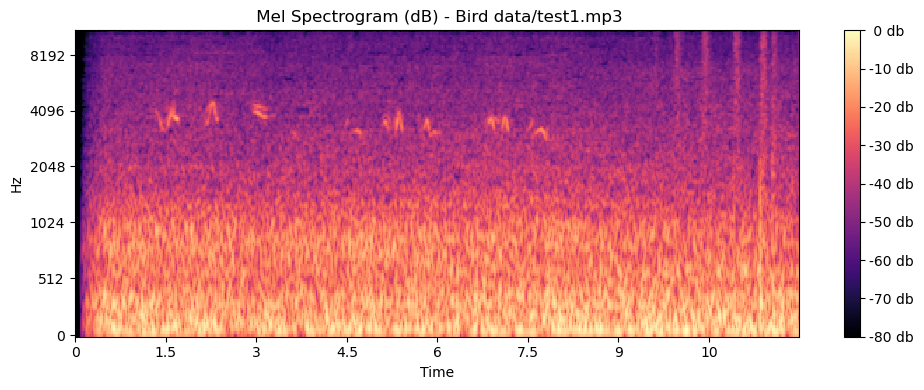

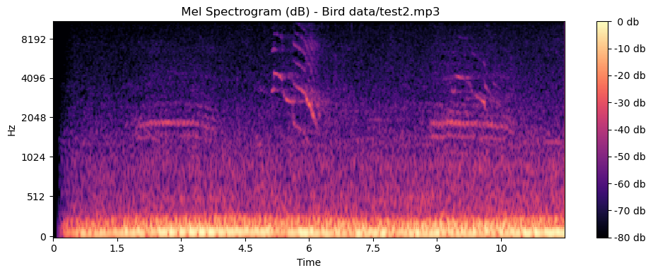

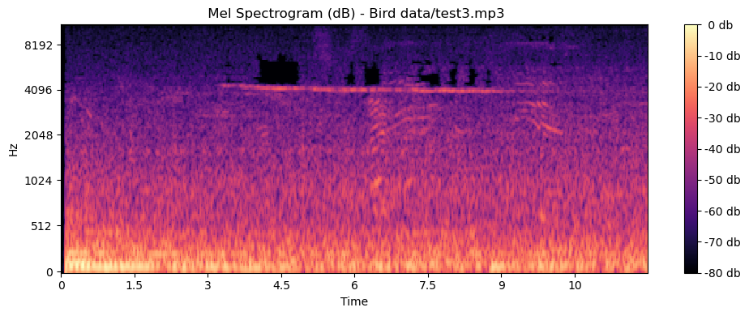

```python
#Create plots for binary model

#Plot the convolutional model:
def plot_convo_mp3 (Bird_data):
    #Load mp3 files:
    y, sr = librosa.load(Bird_data, duration = 3)

    #Compute mel spectrogram:
    spec_convo= librosa.feature.melspectrogram(
        y=y, sr=sr,
        hop_length= 128,
        win_length= 512,
        n_mels= 128
    )
    #Convert spectrogram to decibel:
    spec_convo_decibel= librosa.power_to_db( spec_convo, ref=np.max)
    #Plot
    plt.figure(figsize = (10,4))
    librosa.display.specshow(
        spec_convo_decibel,
        sr=sr,
        x_axis= 'time',
        y_axis= 'mel' ,
        cmap= 'magma'
    )
    plt.colorbar(format= '%2.0f db')
    plt.title (f' Mel Spectrogram (dB) - {Bird_data}')
    plt.tight_layout()
    plt.show()

plot_convo_mp3('Bird data/test1.mp3')
plot_convo_mp3('Bird data/test2.mp3')
plot_convo_mp3('Bird data/test3.mp3')
```

Plot all mel spectrogram to help visualize the audio clips. Each of them got converted to decibel scale to help with visibility and plotted. These plots were used to determine if any of the clips have more than one specie in it. Test clip 2 seem to show there are potentially two species within the audio clip.